# Assignment03

## FIRST IMPORT ALL IMPORTANT LIBRARY FOR THIS TASK

```python
import pandas as pd
import numpy as np
import seaborn as sns
import matplotlib.pyplot as plt
```

```python
A1 = pd.read_csv(r"C:\Users\yakubu Naomi\Downloads\order_types1.csv")
A1
```

|  | order_details_id | order_id | pizza_id | quantity |
| --- | --- | --- | --- | --- |
| 0 | 1 | 1 | hawaiian_m | 1 |
| 1 | 2 | 2 | classic_dlx_m | 1 |
| 2 | 3 | 2 | five_cheese_l | 1 |
| 3 | 4 | 2 | ital_supr_l | 1 |
| 4 | 5 | 2 | mexicana_m | 1 |
| ... | ... | ... | ... | ... |
| 48615 | 48616 | 21348 | ckn_alfredo_m | 1 |
| 48616 | 48617 | 21348 | four_cheese_l | 1 |
| 48617 | 48618 | 21348 | napolitana_s | 1 |
| 48618 | 48619 | 21349 | mexicana_l | 1 |
| 48619 | 48620 | 21350 | bbq_ckn_s | 1 |

48620 rows × 4 columns

```python
A2 = pd.read_csv(r"C:\Users\yakubu Naomi\Downloads\order1.csv")
A2
```

|  | order_id | date | time |
| --- | --- | --- | --- |
| 0 | 1 | 1/1/2015 | 11:38:36 |
| 1 | 2 | 1/1/2015 | 11:57:40 |
| 2 | 3 | 1/1/2015 | 12:12:28 |
| 3 | 4 | 1/1/2015 | 12:16:31 |
| 4 | 5 | 1/1/2015 | 12:21:30 |
| ... | ... | ... | ... |
| 21345 | 21346 | 12/31/2015 | 20:51:07 |
| 21346 | 21347 | 12/31/2015 | 21:14:37 |
| 21347 | 21348 | 12/31/2015 | 21:23:10 |
| 21348 | 21349 | 12/31/2015 | 22:09:54 |
| 21349 | 21350 | 12/31/2015 | 23:02:05 |

21350 rows × 3 columns

```python
A3 = pd.read_csv(r"C:\Users\yakubu Naomi\Downloads\pizza1.csv")
A3
```

|  | pizza_id | pizza_type_id | size | price |
| --- | --- | --- | --- | --- |
| 0 | bbq_ckn_s | bbq_ckn | S | 12.75 |
| 1 | bbq_ckn_m | bbq_ckn | M | 16.75 |
| 2 | bbq_ckn_l | bbq_ckn | L | 20.75 |
| 3 | cali_ckn_s | cali_ckn | S | 12.75 |
| 4 | cali_ckn_m | cali_ckn | M | 16.75 |
| ... | ... | ... | ... | ... |
| 91 | spinach_fet_m | spinach_fet | M | 16.00 |
| 92 | spinach_fet_l | spinach_fet | L | 20.25 |
| 93 | veggie_veg_s | veggie_veg | S | 12.00 |
| 94 | veggie_veg_m | veggie_veg | M | 16.00 |
| 95 | veggie_veg_l | veggie_veg | L | 20.25 |

96 rows × 4 columns

```python
A5 = pd.read_csv(r"C:\Users\yakubu Naomi\Downloads\pizza_types.csv", encoding="latin1")
A5
```

|  | pizza_type_id | name | category | ingredients |
| --- | --- | --- | --- | --- |
| 0 | bbq_ckn | The Barbecue Chicken Pizza | Chicken | Barbecued Chicken, Red Peppers, Green Peppers,... |
| 1 | cali_ckn | The California Chicken Pizza | Chicken | Chicken, Artichoke, Spinach, Garlic, Jalapeno ... |
| 2 | ckn_alfredo | The Chicken Alfredo Pizza | Chicken | Chicken, Red Onions, Red Peppers, Mushrooms, A... |
| 3 | ckn_pesto | The Chicken Pesto Pizza | Chicken | Chicken, Tomatoes, Red Peppers, Spinach, Garli... |
| 4 | southw_ckn | The Southwest Chicken Pizza | Chicken | Chicken, Tomatoes, Red Peppers, Red Onions, Ja... |
| 5 | thai_ckn | The Thai Chicken Pizza | Chicken | Chicken, Pineapple, Tomatoes, Red Peppers, Tha... |
| 6 | big_meat | The Big Meat Pizza | Classic | Bacon, Pepperoni, Italian Sausage, Chorizo Sau... |
| 7 | classic_dlx | The Classic Deluxe Pizza | Classic | Pepperoni, Mushrooms, Red Onions, Red Peppers,... |
| 8 | hawaiian | The Hawaiian Pizza | Classic | Sliced Ham, Pineapple, Mozzarella Cheese |
| 9 | ital_cpcllo | The Italian Capocollo Pizza | Classic | Capocollo, Red Peppers, Tomatoes, Goat Cheese,... |
| 10 | napolitana | The Napolitana Pizza | Classic | Tomatoes, Anchovies, Green Olives, Red Onions,... |
| 11 | pep_msh_pep | The Pepperoni, Mushroom, and Peppers Pizza | Classic | Pepperoni, Mushrooms, Green Peppers |
| 12 | pepperoni | The Pepperoni Pizza | Classic | Mozzarella Cheese, Pepperoni |
| 13 | the_greek | The Greek Pizza | Classic | Kalamata Olives, Feta Cheese, Tomatoes, Garlic... |
| 14 | brie_carre | The Brie Carre Pizza | Supreme | Brie Carre Cheese, Prosciutto, Caramelized Oni... |
| 15 | calabrese | The Calabrese Pizza | Supreme | Nduja Salami, Pancetta, Tomatoes, Red Onions,... |
| 16 | ital_supr | The Italian Supreme Pizza | Supreme | Calabrese Salami, Capocollo, Tomatoes, Red Oni... |
| 17 | peppr_salami | The Pepper Salami Pizza | Supreme | Genoa Salami, Capocollo, Pepperoni, Tomatoes, ... |
| 18 | prsc_argla | The Prosciutto and Arugula Pizza | Supreme | Prosciutto di San Daniele, Arugula, Mozzarella... |
| 19 | sicilian | The Sicilian Pizza | Supreme | Coarse Sicilian Salami, Tomatoes, Green Olives... |
| 20 | soppressata | The Soppressata Pizza | Supreme | Soppressata Salami, Fontina Cheese, Mozzarella... |
| 21 | spicy_ital | The Spicy Italian Pizza | Supreme | Capocollo, Tomatoes, Goat Cheese, Artichokes, ... |
| 22 | spinach_supr | The Spinach Supreme Pizza | Supreme | Spinach, Red Onions, Pepperoni, Tomatoes, Arti... |
| 23 | five_cheese | The Five Cheese Pizza | Veggie | Mozzarella Cheese, Provolone Cheese, Smoked Go... |
| 24 | four_cheese | The Four Cheese Pizza | Veggie | Ricotta Cheese, Gorgonzola Piccante Cheese, Mo... |
| 25 | green_garden | The Green Garden Pizza | Veggie | Spinach, Mushrooms, Tomatoes, Green Olives, Fe... |
| 26 | ital_veggie | The Italian Vegetables Pizza | Veggie | Eggplant, Artichokes, Tomatoes, Zucchini, Red ... |
| 27 | mediterraneo | The Mediterranean Pizza | Veggie | Spinach, Artichokes, Kalamata Olives, Sun-drie... |
| 28 | mexicana | The Mexicana Pizza | Veggie | Tomatoes, Red Peppers, Jalapeno Peppers, Red O... |
| 29 | spin_pesto | The Spinach Pesto Pizza | Veggie | Spinach, Artichokes, Tomatoes, Sun-dried Tomat... |
| 30 | spinach_fet | The Spinach and Feta Pizza | Veggie | Spinach, Mushrooms, Red Onions, Feta Cheese, G... |
| 31 | veggie_veg | The Vegetables + Vegetables Pizza | Veggie | Mushrooms, Tomatoes, Red Peppers, Green Pepper... |

## NEXT I MOVE TO JOINING THE TABLES TO GET A PROPER DATASET WHERE I WILL BE USING LEFT JOINS

```python
A6 = pd.merge(A1, A2, on = 'order_id', how = 'left')
A6
```

|  | order_details_id | order_id | pizza_id | quantity | date | time |
| --- | --- | --- | --- | --- | --- | --- |
| 0 | 1 | 1 | hawaiian_m | 1 | 1/1/2015 | 11:38:36 |
| 1 | 2 | 2 | classic_dlx_m | 1 | 1/1/2015 | 11:57:40 |
| 2 | 3 | 2 | five_cheese_l | 1 | 1/1/2015 | 11:57:40 |
| 3 | 4 | 2 | ital_supr_l | 1 | 1/1/2015 | 11:57:40 |
| 4 | 5 | 2 | mexicana_m | 1 | 1/1/2015 | 11:57:40 |
| ... | ... | ... | ... | ... | ... | ... |
| 48615 | 48616 | 21348 | ckn_alfredo_m | 1 | 12/31/2015 | 21:23:10 |
| 48616 | 48617 | 21348 | four_cheese_l | 1 | 12/31/2015 | 21:23:10 |
| 48617 | 48618 | 21348 | napolitana_s | 1 | 12/31/2015 | 21:23:10 |
| 48618 | 48619 | 21349 | mexicana_l | 1 | 12/31/2015 | 22:09:54 |
| 48619 | 48620 | 21350 | bbq_ckn_s | 1 | 12/31/2015 | 23:02:05 |

48620 rows × 6 columns

```python
A7=pd.merge(A3, A5, on = 'pizza_type_id', how = 'left')
A7
```

|  | pizza_id | pizza_type_id | size | price | name | category | ingredients |
| --- | --- | --- | --- | --- | --- | --- | --- |
| 0 | bbq_ckn_s | bbq_ckn | S | 12.75 | The Barbecue Chicken Pizza | Chicken | Barbecued Chicken, Red Peppers, Green Peppers,... |
| 1 | bbq_ckn_m | bbq_ckn | M | 16.75 | The Barbecue Chicken Pizza | Chicken | Barbecued Chicken, Red Peppers, Green Peppers,... |
| 2 | bbq_ckn_l | bbq_ckn | L | 20.75 | The Barbecue Chicken Pizza | Chicken | Barbecued Chicken, Red Peppers, Green Peppers,... |
| 3 | cali_ckn_s | cali_ckn | S | 12.75 | The California Chicken Pizza | Chicken | Chicken, Artichoke, Spinach, Garlic, Jalapeno ... |
| 4 | cali_ckn_m | cali_ckn | M | 16.75 | The California Chicken Pizza | Chicken | Chicken, Artichoke, Spinach, Garlic, Jalapeno ... |
| ... | ... | ... | ... | ... | ... | ... | ... |
| 91 | spinach_fet_m | spinach_fet | M | 16.00 | The Spinach and Feta Pizza | Veggie | Spinach, Mushrooms, Red Onions, Feta Cheese, G... |
| 92 | spinach_fet_l | spinach_fet | L | 20.25 | The Spinach and Feta Pizza | Veggie | Spinach, Mushrooms, Red Onions, Feta Cheese, G... |
| 93 | veggie_veg_s | veggie_veg | S | 12.00 | The Vegetables + Vegetables Pizza | Veggie | Mushrooms, Tomatoes, Red Peppers, Green Pepper... |
| 94 | veggie_veg_m | veggie_veg | M | 16.00 | The Vegetables + Vegetables Pizza | Veggie | Mushrooms, Tomatoes, Red Peppers, Green Pepper... |
| 95 | veggie_veg_l | veggie_veg | L | 20.25 | The Vegetables + Vegetables Pizza | Veggie | Mushrooms, Tomatoes, Red Peppers, Green Pepper... |

96 rows × 7 columns

```python
df=pd.merge(A6, A7, on = 'pizza_id', how = 'left')
df
```

|  | order_details_id | order_id | pizza_id | quantity | date | time | pizza_type_id | size | price | name | category | ingredients |
| --- | --- | --- | --- | --- | --- | --- | --- | --- | --- | --- | --- | --- |
| 0 | 1 | 1 | hawaiian_m | 1 | 1/1/2015 | 11:38:36 | hawaiian | M | 13.25 | The Hawaiian Pizza | Classic | Sliced Ham, Pineapple, Mozzarella Cheese |
| 1 | 2 | 2 | classic_dlx_m | 1 | 1/1/2015 | 11:57:40 | classic_dlx | M | 16.00 | The Classic Deluxe Pizza | Classic | Pepperoni, Mushrooms, Red Onions, Red Peppers,... |
| 2 | 3 | 2 | five_cheese_l | 1 | 1/1/2015 | 11:57:40 | five_cheese | L | 18.50 | The Five Cheese Pizza | Veggie | Mozzarella Cheese, Provolone Cheese, Smoked Go... |
| 3 | 4 | 2 | ital_supr_l | 1 | 1/1/2015 | 11:57:40 | ital_supr | L | 20.75 | The Italian Supreme Pizza | Supreme | Calabrese Salami, Capocollo, Tomatoes, Red Oni... |
| 4 | 5 | 2 | mexicana_m | 1 | 1/1/2015 | 11:57:40 | mexicana | M | 16.00 | The Mexicana Pizza | Veggie | Tomatoes, Red Peppers, Jalapeno Peppers, Red O... |
| ... | ... | ... | ... | ... | ... | ... | ... | ... | ... | ... | ... | ... |
| 48615 | 48616 | 21348 | ckn_alfredo_m | 1 | 12/31/2015 | 21:23:10 | ckn_alfredo | M | 16.75 | The Chicken Alfredo Pizza | Chicken | Chicken, Red Onions, Red Peppers, Mushrooms, A... |
| 48616 | 48617 | 21348 | four_cheese_l | 1 | 12/31/2015 | 21:23:10 | four_cheese | L | 17.95 | The Four Cheese Pizza | Veggie | Ricotta Cheese, Gorgonzola Piccante Cheese, Mo... |
| 48617 | 48618 | 21348 | napolitana_s | 1 | 12/31/2015 | 21:23:10 | napolitana | S | 12.00 | The Napolitana Pizza | Classic | Tomatoes, Anchovies, Green Olives, Red Onions,... |
| 48618 | 48619 | 21349 | mexicana_l | 1 | 12/31/2015 | 22:09:54 | mexicana | L | 20.25 | The Mexicana Pizza | Veggie | Tomatoes, Red Peppers, Jalapeno Peppers, Red O... |
| 48619 | 48620 | 21350 | bbq_ckn_s | 1 | 12/31/2015 | 23:02:05 | bbq_ckn | S | 12.75 | The Barbecue Chicken Pizza | Chicken | Barbecued Chicken, Red Peppers, Green Peppers,... |

48620 rows × 12 columns

```python
df.shape
```

```
(48620, 12)
```

```python
df.info()
```

```
<class 'pandas.core.frame.DataFrame'>
RangeIndex: 48620 entries, 0 to 48619
Data columns (total 12 columns):
 #   Column            Non-Null Count  Dtype
---  ------            --------------  -----
 0   order_details_id  48620 non-null  int64
 1   order_id          48620 non-null  int64
 2   pizza_id          48620 non-null  object
 3   quantity          48620 non-null  int64
 4   date              48620 non-null  object
 5   time              48620 non-null  object
 6   pizza_type_id     48620 non-null  object
 7   size              48620 non-null  object
 8   price             48620 non-null  float64
 9   name              48620 non-null  object
 10  category          48620 non-null  object
 11  ingredients       48620 non-null  object
dtypes: float64(1), int64(3), object(8)
memory usage: 4.5+ MB
```

```python
df.head()
```

|  | order_details_id | order_id | pizza_id | quantity | date | time | pizza_type_id | size | price | name | category | ingredients |
| --- | --- | --- | --- | --- | --- | --- | --- | --- | --- | --- | --- | --- |
| 0 | 1 | 1 | hawaiian_m | 1 | 1/1/2015 | 11:38:36 | hawaiian | M | 13.25 | The Hawaiian Pizza | Classic | Sliced Ham, Pineapple, Mozzarella Cheese |
| 1 | 2 | 2 | classic_dlx_m | 1 | 1/1/2015 | 11:57:40 | classic_dlx | M | 16.00 | The Classic Deluxe Pizza | Classic | Pepperoni, Mushrooms, Red Onions, Red Peppers,... |
| 2 | 3 | 2 | five_cheese_l | 1 | 1/1/2015 | 11:57:40 | five_cheese | L | 18.50 | The Five Cheese Pizza | Veggie | Mozzarella Cheese, Provolone Cheese, Smoked Go... |
| 3 | 4 | 2 | ital_supr_l | 1 | 1/1/2015 | 11:57:40 | ital_supr | L | 20.75 | The Italian Supreme Pizza | Supreme | Calabrese Salami, Capocollo, Tomatoes, Red Oni... |
| 4 | 5 | 2 | mexicana_m | 1 | 1/1/2015 | 11:57:40 | mexicana | M | 16.00 | The Mexicana Pizza | Veggie | Tomatoes, Red Peppers, Jalapeno Peppers, Red O... |

```python
df.tail()
```

|  | order_details_id | order_id | pizza_id | quantity | date | time | pizza_type_id | size | price | name | category | ingredients |
| --- | --- | --- | --- | --- | --- | --- | --- | --- | --- | --- | --- | --- |
| 48615 | 48616 | 21348 | ckn_alfredo_m | 1 | 12/31/2015 | 21:23:10 | ckn_alfredo | M | 16.75 | The Chicken Alfredo Pizza | Chicken | Chicken, Red Onions, Red Peppers, Mushrooms, A... |
| 48616 | 48617 | 21348 | four_cheese_l | 1 | 12/31/2015 | 21:23:10 | four_cheese | L | 17.95 | The Four Cheese Pizza | Veggie | Ricotta Cheese, Gorgonzola Piccante Cheese, Mo... |
| 48617 | 48618 | 21348 | napolitana_s | 1 | 12/31/2015 | 21:23:10 | napolitana | S | 12.00 | The Napolitana Pizza | Classic | Tomatoes, Anchovies, Green Olives, Red Onions,... |
| 48618 | 48619 | 21349 | mexicana_l | 1 | 12/31/2015 | 22:09:54 | mexicana | L | 20.25 | The Mexicana Pizza | Veggie | Tomatoes, Red Peppers, Jalapeno Peppers, Red O... |
| 48619 | 48620 | 21350 | bbq_ckn_s | 1 | 12/31/2015 | 23:02:05 | bbq_ckn | S | 12.75 | The Barbecue Chicken Pizza | Chicken | Barbecued Chicken, Red Peppers, Green Peppers,... |

## AFTER CHECKING .INFO, FOUNDOUT THE DATATYPE FOR TIME AND DATE NEED LITTLE ADJUSTMENT.

```python
df['date']= pd.to_datetime(df['date'])
df
```

|  | order_details_id | order_id | pizza_id | quantity | date | time | pizza_type_id | size | price | name | category | ingredients |
| --- | --- | --- | --- | --- | --- | --- | --- | --- | --- | --- | --- | --- |
| 0 | 1 | 1 | hawaiian_m | 1 | 2015-01-01 | 11:38:36 | hawaiian | M | 13.25 | The Hawaiian Pizza | Classic | Sliced Ham, Pineapple, Mozzarella Cheese |
| 1 | 2 | 2 | classic_dlx_m | 1 | 2015-01-01 | 11:57:40 | classic_dlx | M | 16.00 | The Classic Deluxe Pizza | Classic | Pepperoni, Mushrooms, Red Onions, Red Peppers,... |
| 2 | 3 | 2 | five_cheese_l | 1 | 2015-01-01 | 11:57:40 | five_cheese | L | 18.50 | The Five Cheese Pizza | Veggie | Mozzarella Cheese, Provolone Cheese, Smoked Go... |
| 3 | 4 | 2 | ital_supr_l | 1 | 2015-01-01 | 11:57:40 | ital_supr | L | 20.75 | The Italian Supreme Pizza | Supreme | Calabrese Salami, Capocollo, Tomatoes, Red Oni... |
| 4 | 5 | 2 | mexicana_m | 1 | 2015-01-01 | 11:57:40 | mexicana | M | 16.00 | The Mexicana Pizza | Veggie | Tomatoes, Red Peppers, Jalapeno Peppers, Red O... |
| ... | ... | ... | ... | ... | ... | ... | ... | ... | ... | ... | ... | ... |
| 48615 | 48616 | 21348 | ckn_alfredo_m | 1 | 2015-12-31 | 21:23:10 | ckn_alfredo | M | 16.75 | The Chicken Alfredo Pizza | Chicken | Chicken, Red Onions, Red Peppers, Mushrooms, A... |
| 48616 | 48617 | 21348 | four_cheese_l | 1 | 2015-12-31 | 21:23:10 | four_cheese | L | 17.95 | The Four Cheese Pizza | Veggie | Ricotta Cheese, Gorgonzola Piccante Cheese, Mo... |
| 48617 | 48618 | 21348 | napolitana_s | 1 | 2015-12-31 | 21:23:10 | napolitana | S | 12.00 | The Napolitana Pizza | Classic | Tomatoes, Anchovies, Green Olives, Red Onions,... |
| 48618 | 48619 | 21349 | mexicana_l | 1 | 2015-12-31 | 22:09:54 | mexicana | L | 20.25 | The Mexicana Pizza | Veggie | Tomatoes, Red Peppers, Jalapeno Peppers, Red O... |
| 48619 | 48620 | 21350 | bbq_ckn_s | 1 | 2015-12-31 | 23:02:05 | bbq_ckn | S | 12.75 | The Barbecue Chicken Pizza | Chicken | Barbecued Chicken, Red Peppers, Green Peppers,... |

48620 rows × 12 columns

```python
df.info()
```

```
<class 'pandas.core.frame.DataFrame'>
RangeIndex: 48620 entries, 0 to 48619
Data columns (total 12 columns):
 #   Column            Non-Null Count  Dtype
---  ------            --------------  -----
 0   order_details_id  48620 non-null  int64
 1   order_id          48620 non-null  int64
 2   pizza_id          48620 non-null  object
 3   quantity          48620 non-null  int64
 4   date              48620 non-null  datetime64[ns]
 5   time              48620 non-null  object
 6   pizza_type_id     48620 non-null  object
 7   size              48620 non-null  object
 8   price             48620 non-null  float64
 9   name              48620 non-null  object
 10  category          48620 non-null  object
 11  ingredients       48620 non-null  object
dtypes: datetime64[ns](1), float64(1), int64(3), object(7)
memory usage: 4.5+ MB
```

```python
df.duplicated().sum()
```

```
0
```

```python
df.isna().sum()
```

```
order_details_id    0
order_id            0
pizza_id            0
quantity            0
date                0
time                0
pizza_type_id       0
size                0
price               0
name                0
category            0
ingredients         0
dtype: int64
```

```python
df.describe()
```

|  | order_details_id | order_id | quantity | date | price |
| --- | --- | --- | --- | --- | --- |
| count | 48620.000000 | 48620.000000 | 48620.000000 | 48620 | 48620.000000 |
| mean | 24310.500000 | 10701.479761 | 1.019622 | 2015-06-29 11:03:43.611682560 | 16.494132 |
| min | 1.000000 | 1.000000 | 1.000000 | 2015-01-01 00:00:00 | 9.750000 |
| 25% | 12155.750000 | 5337.000000 | 1.000000 | 2015-03-31 00:00:00 | 12.750000 |
| 50% | 24310.500000 | 10682.500000 | 1.000000 | 2015-06-28 00:00:00 | 16.500000 |
| 75% | 36465.250000 | 16100.000000 | 1.000000 | 2015-09-28 00:00:00 | 20.250000 |
| max | 48620.000000 | 21350.000000 | 4.000000 | 2015-12-31 00:00:00 | 35.950000 |
| std | 14035.529381 | 6180.119770 | 0.143077 | NaN | 3.621789 |

## AFTER JOINING THE TABLES, I CHECKED THE DATASET FOR NAS,DUPLICATE, AND ANY IRREGULARITIES. BUT IT IS CLEAN AND READY FOR MANIPULATIONS..

- NUMBER 1 : What is the total revenue/sales?

```python
df['Revenue'] = df['quantity'] * df['price']
Total_revenue = df['Revenue'].sum()
print('Total_revenue:',Total_revenue )
```

```
Total_revenue: 817860.05
```

- NUMBER 2: Find the total quantity sold.

```python
total_quantity_sold = df['quantity'].sum()
print('total_quantity_sold:', total_quantity_sold)
```

```
total_quantity_sold: 49574
```

- NUMBER 3: Find the total orders.

```python
total_orders = df['order_details_id'].count()
print('total_orders:', total_orders)
```

```
total_orders: 48620
```

- NUMBER 4: How many pizza types do they sell?

```python
number_of_pizza_type = df['name'].nunique()
print('number_of_pizza_type:', number_of_pizza_type)
```

```
number_of_pizza_type: 32
```

- NUMBER 5: Find the average price of pizzas

```python
avg_price = df['price'].mean()
print('avg_price:', avg_price )
```

```
avg_price: 16.494132044426163
```

- NUMBER 6: Whate are the peak hour of sales?

```python
sales_sum = df.groupby('time')['price'].sum()  # total sales par hour
sales_sum
```

```
time
10:25:19    12.50
10:34:34    53.25
10:43:04    52.75
10:50:46    50.25
10:52:26    28.75
            ...
23:05:16    26.00
23:05:17    40.00
23:05:24    61.50
23:05:52    32.50
9:52:21     83.00
Name: price, Length: 16382, dtype: float64
```

```python
top5_sales = sales_sum.sort_values(ascending= False).head(5)
print('\nTop 5 peak hours by sales price:')
print(top5_sales)
```

```
Top 5 peak hours by sales price:
time
12:32:00    448.20
12:53:29    387.00
11:59:10    379.00
12:26:04    377.40
12:52:36    367.75
Name: price, dtype: float64
```

## NUMBER 7: Find the total sale made on each day of the week. which day of the week is when sales are made the most

- TO GET THIS DONE, I NEED TO EXTRACT DAYS OF THE WEEK FROM DATE COLUMN.. TO GET ANOTHER COLUMN FOR DAY OF THE WEEK.

```python
df
```

|  | order_details_id | order_id | pizza_id | quantity | date | time | pizza_type_id | size | price | name | category | ingredients | Revenue |
| --- | --- | --- | --- | --- | --- | --- | --- | --- | --- | --- | --- | --- | --- |
| 0 | 1 | 1 | hawaiian_m | 1 | 2015-01-01 | 11:38:36 | hawaiian | M | 13.25 | The Hawaiian Pizza | Classic | Sliced Ham, Pineapple, Mozzarella Cheese | 13.25 |
| 1 | 2 | 2 | classic_dlx_m | 1 | 2015-01-01 | 11:57:40 | classic_dlx | M | 16.00 | The Classic Deluxe Pizza | Classic | Pepperoni, Mushrooms, Red Onions, Red Peppers,... | 16.00 |
| 2 | 3 | 2 | five_cheese_l | 1 | 2015-01-01 | 11:57:40 | five_cheese | L | 18.50 | The Five Cheese Pizza | Veggie | Mozzarella Cheese, Provolone Cheese, Smoked Go... | 18.50 |
| 3 | 4 | 2 | ital_supr_l | 1 | 2015-01-01 | 11:57:40 | ital_supr | L | 20.75 | The Italian Supreme Pizza | Supreme | Calabrese Salami, Capocollo, Tomatoes, Red Oni... | 20.75 |
| 4 | 5 | 2 | mexicana_m | 1 | 2015-01-01 | 11:57:40 | mexicana | M | 16.00 | The Mexicana Pizza | Veggie | Tomatoes, Red Peppers, Jalapeno Peppers, Red O... | 16.00 |
| ... | ... | ... | ... | ... | ... | ... | ... | ... | ... | ... | ... | ... | ... |
| 48615 | 48616 | 21348 | ckn_alfredo_m | 1 | 2015-12-31 | 21:23:10 | ckn_alfredo | M | 16.75 | The Chicken Alfredo Pizza | Chicken | Chicken, Red Onions, Red Peppers, Mushrooms, A... | 16.75 |
| 48616 | 48617 | 21348 | four_cheese_l | 1 | 2015-12-31 | 21:23:10 | four_cheese | L | 17.95 | The Four Cheese Pizza | Veggie | Ricotta Cheese, Gorgonzola Piccante Cheese, Mo... | 17.95 |
| 48617 | 48618 | 21348 | napolitana_s | 1 | 2015-12-31 | 21:23:10 | napolitana | S | 12.00 | The Napolitana Pizza | Classic | Tomatoes, Anchovies, Green Olives, Red Onions,... | 12.00 |
| 48618 | 48619 | 21349 | mexicana_l | 1 | 2015-12-31 | 22:09:54 | mexicana | L | 20.25 | The Mexicana Pizza | Veggie | Tomatoes, Red Peppers, Jalapeno Peppers, Red O... | 20.25 |
| 48619 | 48620 | 21350 | bbq_ckn_s | 1 | 2015-12-31 | 23:02:05 | bbq_ckn | S | 12.75 | The Barbecue Chicken Pizza | Chicken | Barbecued Chicken, Red Peppers, Green Peppers,... | 12.75 |

48620 rows × 13 columns

```python
df['day_of_week'] = df['date'].dt.day_name()
df
```

|  | order_details_id | order_id | pizza_id | quantity | date | time | pizza_type_id | size | price | name | category | ingredients | Revenue | day_of_week |
| --- | --- | --- | --- | --- | --- | --- | --- | --- | --- | --- | --- | --- | --- | --- |
| 0 | 1 | 1 | hawaiian_m | 1 | 2015-01-01 | 11:38:36 | hawaiian | M | 13.25 | The Hawaiian Pizza | Classic | Sliced Ham, Pineapple, Mozzarella Cheese | 13.25 | Thursday |
| 1 | 2 | 2 | classic_dlx_m | 1 | 2015-01-01 | 11:57:40 | classic_dlx | M | 16.00 | The Classic Deluxe Pizza | Classic | Pepperoni, Mushrooms, Red Onions, Red Peppers,... | 16.00 | Thursday |
| 2 | 3 | 2 | five_cheese_l | 1 | 2015-01-01 | 11:57:40 | five_cheese | L | 18.50 | The Five Cheese Pizza | Veggie | Mozzarella Cheese, Provolone Cheese, Smoked Go... | 18.50 | Thursday |
| 3 | 4 | 2 | ital_supr_l | 1 | 2015-01-01 | 11:57:40 | ital_supr | L | 20.75 | The Italian Supreme Pizza | Supreme | Calabrese Salami, Capocollo, Tomatoes, Red Oni... | 20.75 | Thursday |
| 4 | 5 | 2 | mexicana_m | 1 | 2015-01-01 | 11:57:40 | mexicana | M | 16.00 | The Mexicana Pizza | Veggie | Tomatoes, Red Peppers, Jalapeno Peppers, Red O... | 16.00 | Thursday |
| ... | ... | ... | ... | ... | ... | ... | ... | ... | ... | ... | ... | ... | ... | ... |
| 48615 | 48616 | 21348 | ckn_alfredo_m | 1 | 2015-12-31 | 21:23:10 | ckn_alfredo | M | 16.75 | The Chicken Alfredo Pizza | Chicken | Chicken, Red Onions, Red Peppers, Mushrooms, A... | 16.75 | Thursday |
| 48616 | 48617 | 21348 | four_cheese_l | 1 | 2015-12-31 | 21:23:10 | four_cheese | L | 17.95 | The Four Cheese Pizza | Veggie | Ricotta Cheese, Gorgonzola Piccante Cheese, Mo... | 17.95 | Thursday |
| 48617 | 48618 | 21348 | napolitana_s | 1 | 2015-12-31 | 21:23:10 | napolitana | S | 12.00 | The Napolitana Pizza | Classic | Tomatoes, Anchovies, Green Olives, Red Onions,... | 12.00 | Thursday |
| 48618 | 48619 | 21349 | mexicana_l | 1 | 2015-12-31 | 22:09:54 | mexicana | L | 20.25 | The Mexicana Pizza | Veggie | Tomatoes, Red Peppers, Jalapeno Peppers, Red O... | 20.25 | Thursday |
| 48619 | 48620 | 21350 | bbq_ckn_s | 1 | 2015-12-31 | 23:02:05 | bbq_ckn | S | 12.75 | The Barbecue Chicken Pizza | Chicken | Barbecued Chicken, Red Peppers, Green Peppers,... | 12.75 | Thursday |

48620 rows × 14 columns

```python
sales_par_day = df.groupby('day_of_week')['Revenue'].sum()
print(sales_par_day)
```

```
day_of_week
Friday       136073.90
Monday       107329.55
Saturday     123182.40
Sunday        99203.50
Thursday     123528.50
Tuesday      114133.80
Wednesday    114408.40
Name: Revenue, dtype: float64
```

```python
Highest_sales_day = sales_par_day.idxmax()
print('Day With The Highest Sales:', Highest_sales_day)
```

```
Day With The Highest Sales: Friday
```

```python
top3_highest_sales_days = sales_par_day.sort_values(ascending= False).head(3)
print('\nTop 3 highest sales days :')
print(top3_highest_sales_days)
```

```
Top 3 highest sales days :
day_of_week
Friday      136073.9
Thursday    123528.5
Saturday    123182.4
Name: Revenue, dtype: float64
```

- NUMBER 8: Find the top 5 Bestselling pizzas

```python
Bestselling_pizza = df.groupby('name')['price'].sum()
Bestselling_pizza
```

```
name
The Barbecue Chicken Pizza                    41683.00
The Big Meat Pizza                            21732.00
The Brie Carre Pizza                          11352.00
The Calabrese Pizza                           15763.75
The California Chicken Pizza                  40166.50
The Chicken Alfredo Pizza                     16779.00
The Chicken Pesto Pizza                       16484.75
The Classic Deluxe Pizza                      37631.50
The Five Cheese Pizza                         25141.50
The Four Cheese Pizza                         31361.10
The Greek Pizza                               28170.10
The Green Garden Pizza                        13819.50
The Hawaiian Pizza                            31561.75
The Italian Capocollo Pizza                   24641.50
The Italian Supreme Pizza                     32856.25
The Italian Vegetables Pizza                  15930.75
The Mediterranean Pizza                       15163.00
The Mexicana Pizza                            26243.00
The Napolitana Pizza                          23850.50
The Pepper Salami Pizza                       25081.00
The Pepperoni Pizza                           29538.25
The Pepperoni, Mushroom, and Peppers Pizza    18607.00
The Prosciutto and Arugula Pizza              23679.75
The Sicilian Pizza                            30123.75
The Soppressata Pizza                         16342.75
The Southwest Chicken Pizza                   34081.75
The Spicy Italian Pizza                       34163.50
The Spinach Pesto Pizza                       15388.25
The Spinach Supreme Pizza                     15124.00
The Spinach and Feta Pizza                    23021.25
The Thai Chicken Pizza                        42332.25
The Vegetables + Vegetables Pizza             24129.75
Name: price, dtype: float64
```

```python
Bestselling_pizza_top5 = Bestselling_pizza.sort_values(ascending= False).head(5)
print('\nTop 5 Bestselling Pizza :')
print(Bestselling_pizza_top5)
```

```
Top 5 Bestselling Pizza :
name
The Thai Chicken Pizza          42332.25
The Barbecue Chicken Pizza      41683.00
The California Chicken Pizza    40166.50
The Classic Deluxe Pizza        37631.50
The Spicy Italian Pizza         34163.50
Name: price, dtype: float64
```

- NUMBER 9:Find the sales made in each moth. Any trend noticeable?

```python
df['month'] = df['date'].dt.month_name()
df['month_number'] = df['date'].dt.month # extract months and month number from the date column
df
```

|  | order_details_id | order_id | pizza_id | quantity | date | time | pizza_type_id | size | price | name | category | ingredients | Revenue | day_of_week | month | month_number |
| --- | --- | --- | --- | --- | --- | --- | --- | --- | --- | --- | --- | --- | --- | --- | --- | --- |
| 0 | 1 | 1 | hawaiian_m | 1 | 2015-01-01 | 11:38:36 | hawaiian | M | 13.25 | The Hawaiian Pizza | Classic | Sliced Ham, Pineapple, Mozzarella Cheese | 13.25 | Thursday | January | 1 |
| 1 | 2 | 2 | classic_dlx_m | 1 | 2015-01-01 | 11:57:40 | classic_dlx | M | 16.00 | The Classic Deluxe Pizza | Classic | Pepperoni, Mushrooms, Red Onions, Red Peppers,... | 16.00 | Thursday | January | 1 |
| 2 | 3 | 2 | five_cheese_l | 1 | 2015-01-01 | 11:57:40 | five_cheese | L | 18.50 | The Five Cheese Pizza | Veggie | Mozzarella Cheese, Provolone Cheese, Smoked Go... | 18.50 | Thursday | January | 1 |
| 3 | 4 | 2 | ital_supr_l | 1 | 2015-01-01 | 11:57:40 | ital_supr | L | 20.75 | The Italian Supreme Pizza | Supreme | Calabrese Salami, Capocollo, Tomatoes, Red Oni... | 20.75 | Thursday | January | 1 |
| 4 | 5 | 2 | mexicana_m | 1 | 2015-01-01 | 11:57:40 | mexicana | M | 16.00 | The Mexicana Pizza | Veggie | Tomatoes, Red Peppers, Jalapeno Peppers, Red O... | 16.00 | Thursday | January | 1 |
| ... | ... | ... | ... | ... | ... | ... | ... | ... | ... | ... | ... | ... | ... | ... | ... | ... |
| 48615 | 48616 | 21348 | ckn_alfredo_m | 1 | 2015-12-31 | 21:23:10 | ckn_alfredo | M | 16.75 | The Chicken Alfredo Pizza | Chicken | Chicken, Red Onions, Red Peppers, Mushrooms, A... | 16.75 | Thursday | December | 12 |
| 48616 | 48617 | 21348 | four_cheese_l | 1 | 2015-12-31 | 21:23:10 | four_cheese | L | 17.95 | The Four Cheese Pizza | Veggie | Ricotta Cheese, Gorgonzola Piccante Cheese, Mo... | 17.95 | Thursday | December | 12 |
| 48617 | 48618 | 21348 | napolitana_s | 1 | 2015-12-31 | 21:23:10 | napolitana | S | 12.00 | The Napolitana Pizza | Classic | Tomatoes, Anchovies, Green Olives, Red Onions,... | 12.00 | Thursday | December | 12 |
| 48618 | 48619 | 21349 | mexicana_l | 1 | 2015-12-31 | 22:09:54 | mexicana | L | 20.25 | The Mexicana Pizza | Veggie | Tomatoes, Red Peppers, Jalapeno Peppers, Red O... | 20.25 | Thursday | December | 12 |
| 48619 | 48620 | 21350 | bbq_ckn_s | 1 | 2015-12-31 | 23:02:05 | bbq_ckn | S | 12.75 | The Barbecue Chicken Pizza | Chicken | Barbecued Chicken, Red Peppers, Green Peppers,... | 12.75 | Thursday | December | 12 |

48620 rows × 16 columns

```python
monthly_sales = (
    df.groupby(['month_number', 'month'])['Revenue']
    .sum()
    .reset_index()
    .sort_values('month_number')
)

print(monthly_sales[['month', 'Revenue']])
```

```
        month   Revenue
0     January  69793.30
1    February  65159.60
2       March  70397.10
3       April  68736.80
4         May  71402.75
5        June  68230.20
6        July  72557.90
7      August  68278.25
8   September  64180.05
9     October  64027.60
10   November  70395.35
11   December  64701.15
```

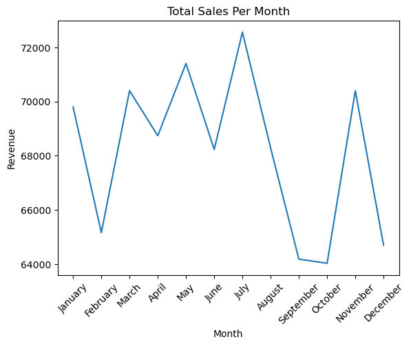

```python
plt.figure()
plt.plot(monthly_sales['month'], monthly_sales['Revenue'])
plt.xticks(rotation=45)
plt.title("Total Sales Per Month")
plt.xlabel("Month")
plt.ylabel("Revenue")
plt.show()
```

- NUMBER 10: Are there any pizza type that are not doing well on the menu?

```python
low_quantity = (df.groupby('name')['quantity'].sum().sort_values().head(5))

print("Bottom 5 Pizzas by Quantity Sold:")
print(low_quantity)
```

```
Bottom 5 Pizzas by Quantity Sold:
name
The Brie Carre Pizza         490
The Mediterranean Pizza      934
The Calabrese Pizza          937
The Spinach Supreme Pizza    950
The Soppressata Pizza        961
Name: quantity, dtype: int64
```

```python
low_revenue = (df.groupby('name')['Revenue'].sum().sort_values().head(5))

print("Bottom 5 Pizzas by Revenue:")
print(low_revenue)
```

```
Bottom 5 Pizzas by Revenue:
name
The Brie Carre Pizza         11588.50
The Green Garden Pizza       13955.75
The Spinach Supreme Pizza    15277.75
The Mediterranean Pizza      15360.50
The Spinach Pesto Pizza      15596.00
Name: Revenue, dtype: float64
```